# Analysis of Pitchfork Music Reviews

# Introduction

Hello! Welcome to an analysis of 18 years of everyone’s favorite cool music website, pitchfork.com. This data was generously uploaded by Nolan Conway at Kaggle and can be found at https://www.kaggle.com/nolanbconaway/pitchfork-data. Mr. Conway uploaded the data in a sqlite database; for this project, I parsed the tables into CSVs and merged the relevant ones into a single dataframe.

There’s a lot to explore here. Have album scores changed overtime? Do the sages of Pitchfork betray preferences for different genres, artists or labels? Do different classes of writers dole out differnet judgment? And perhaps most interesting, are score ranges associated with different language in the reviews? With more than 18,000 rows in this dataset, we’ll soon find out!

A note on the data: First, some of this was processed in Python, which I think is far more functional than R for splitting strings, getting word counts, running functions in grouped dataframes, and so on. The new columns in this dataset that are not in the original SQLite file are one for the split review contents, one for a counter of each word used in those reviews, and one for the length of each review. Second, the fact that this was originally stored in a SQLite file meant that when the tables were merged into the dataframe, there was a fair number of duplicate rows, as a new row was created if an album had more than one label or genre. That sometimes resulted in single albums containing dozens of rows. (One of Radiohead’s album had 32 rows lol.) Thus, there could be a slight loss of resolution when analyses include genres or labels.

With that said, let’s wind our way through this thing.

# Summary statistics

Here’s a bird’s-eye view of our dataset:

```
## 'data.frame':    18389 obs. of  16 variables:
##  $ reviewid      : int  1 6 7 8 10 11 12 15 16 17 ...
##  $ title         : Factor w/ 17832 levels "","'...and farewell to hightide/lighthouse in athens' and 'elements of structure/permanence'",..: 17729 11414 10555 2057 594 6518 599 8646 6414 627 ...
##  $ artist        : Factor w/ 8715 levels "","-ziq","-ziq, kazumi",..: 90 81 81 81 86 89 92 105 105 105 ...
##  $ url           : Factor w/ 18389 levels "http://pitchfork.com/reviews/albums/1-young-forever/",..: 1 15332 16000 16668 2 1017 2030 5116 6171 7158 ...
##  $ score         : num  3.4 7.4 8.1 7.2 8 7 7 6.7 7.5 7.3 ...
##  $ best_new_music: int  0 0 0 0 0 0 0 0 0 0 ...
##  $ author        : Factor w/ 423 levels "aaron leitko",..: 247 132 84 367 283 193 68 29 216 115 ...
##  $ author_type   : Factor w/ 16 levels "","assistant editor",..: 15 8 1 1 1 8 1 8 8 1 ...
##  $ pub_date      : Factor w/ 3950 levels "1999-01-05","1999-01-12",..: 944 618 402 1040 395 522 174 664 592 174 ...
##  $ pub_weekday   : int  0 1 3 6 1 0 6 6 6 6 ...
##  $ pub_day       : int  30 8 16 6 7 4 31 15 2 31 ...
##  $ pub_month     : int  8 4 5 2 5 11 12 6 3 12 ...
##  $ pub_year      : int  2004 2003 2002 2005 2002 2002 2000 2003 2003 2000 ...
##  $ genre         : Factor w/ 10 levels "","electronic",..: 10 2 2 2 6 10 7 9 9 10 ...
##  $ label         : Factor w/ 3404 levels "","!k7","~scape",..: 2552 2675 733 733 3101 356 2711 769 2380 2380 ...
##  $ length        : int  549 672 635 365 320 499 600 811 550 843 ...
```

```
##     reviewid               title                    artist
##  Min.   :    1   dj-kicks     :   20   various artists :  687
##  1st Qu.: 7444   ii           :   17   guided by voices:   23
##  Median :12806   live         :    9   david bowie     :   21
##  Mean   :12346   iii          :    8   the beatles     :   21
##  3rd Qu.:17659   greatest hits:    7   mogwai          :   20
##  Max.   :22745   dj kicks     :    6   of montreal     :   20
##                  (Other)      :18322   (Other)         :17597
##                                                               url
##  http://pitchfork.com/reviews/albums/1-young-forever/           :    1
##  http://pitchfork.com/reviews/albums/10-abcs/                   :    1
##  http://pitchfork.com/reviews/albums/100-one-day-ill-be-on-time/:    1
##  http://pitchfork.com/reviews/albums/1000-dents-and-shells/     :    1
##  http://pitchfork.com/reviews/albums/10000-steingarten/         :    1
##  http://pitchfork.com/reviews/albums/10001-touch-up/            :    1
##  (Other)                                                        :18383
##      score        best_new_music                   author
##  Min.   : 0.000   Min.   :0.00000   joe tangari       :  815
##  1st Qu.: 6.400   1st Qu.:0.00000   stephen m. deusner:  725
##  Median : 7.200   Median :0.00000   ian cohen         :  699
##  Mean   : 7.006   Mean   :0.05128   brian howe        :  500
##  3rd Qu.: 7.800   3rd Qu.:0.00000   mark richardson   :  476
##  Max.   :10.000   Max.   :1.00000   stuart berman     :  445
##                                     (Other)           :14729
##               author_type          pub_date      pub_weekday
##  contributor        :12420   2000-03-31:   15   Min.   :0.000
##                     : 3904   2000-04-30:   14   1st Qu.:1.000
##  senior editor      :  486   2001-03-31:   13   Median :2.000
##  executive editor   :  475   1999-04-20:   12   Mean   :2.107
##  senior staff writer:  439   2001-02-20:   11   3rd Qu.:3.000
##  contributing editor:  210   1999-06-08:   10   Max.   :6.000
##  (Other)            :  455   (Other)   :18314
##     pub_day        pub_month         pub_year             genre
##  Min.   : 1.00   Min.   : 1.000   Min.   :1999   rock        :7815
##  1st Qu.: 8.00   1st Qu.: 3.000   1st Qu.:2005   electronic  :2900
##  Median :15.00   Median : 6.000   Median :2009               :2365
##  Mean   :15.53   Mean   : 6.283   Mean   :2009   rap         :1413
##  3rd Qu.:23.00   3rd Qu.: 9.000   3rd Qu.:2013   experimental:1141
##  Max.   :31.00   Max.   :12.000   Max.   :2017   pop/r&b     :1128
##                                                  (Other)     :1627
##            label           length
##  self-released:  419   Min.   :   0.0
##  drag city    :  263   1st Qu.: 498.0
##  sub pop      :  261   Median : 604.0
##  thrill jockey:  241   Mean   : 650.1
##  merge        :  231   3rd Qu.: 746.0
##  warp         :  210   Max.   :3688.0
##  (Other)      :16764
```

Already, some points arise:

1. Compliations abound, with “Various Artists” having 687 albums. The single most reviewed group/artist is Guided By Voices—I don’t even know what that is.
2. An album’s inclusion in Pitchfork’s annual end-of-year Best New Music is indicated by a 1, rather than by the ranking in the BNM list, which is too bad, but good on Mr. Conway to think of including this in the scraping.
3. All the top publishing days for the website in the summary function come up from the early years of Pitchfork, which was founded in January 1999.
4. There are individual writers who have contributed hundreds and hundreds of reviews.
5. The DJ Kicks mixtapes are the most reviewed series of album.
6. Too many artists make album series titled with Roman numerals.
7. Of Monteal has 20 reviews which seems excessive.

Let’s take a look at how the scores fall:

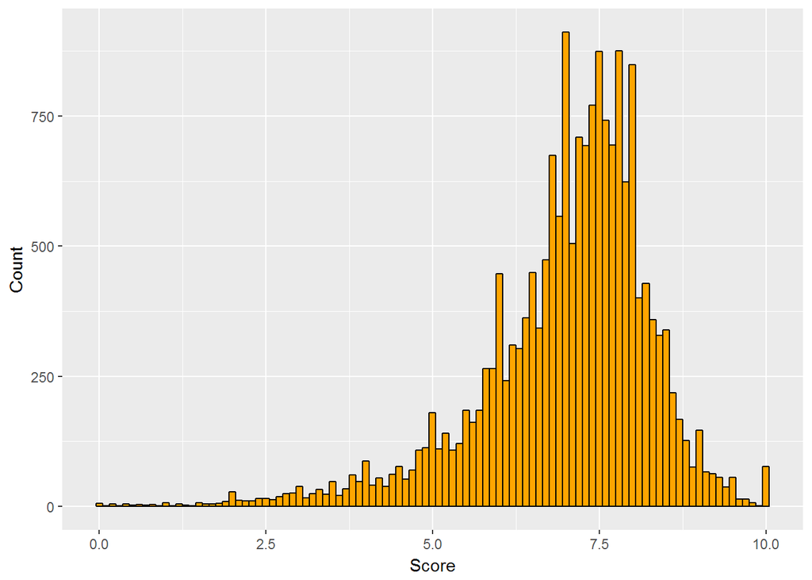

```
##    Min. 1st Qu.  Median    Mean 3rd Qu.    Max.
##   0.000   6.400   7.200   7.006   7.800  10.000
```

Pitchfork, it seems, grades on a curve—if you release an album, you’re likely to get something near a C.

# Breaking down scoring factors

## Genre

The fun of the dataset is how many angles it provides to look at scores. Let’s start by taking a look at genres.

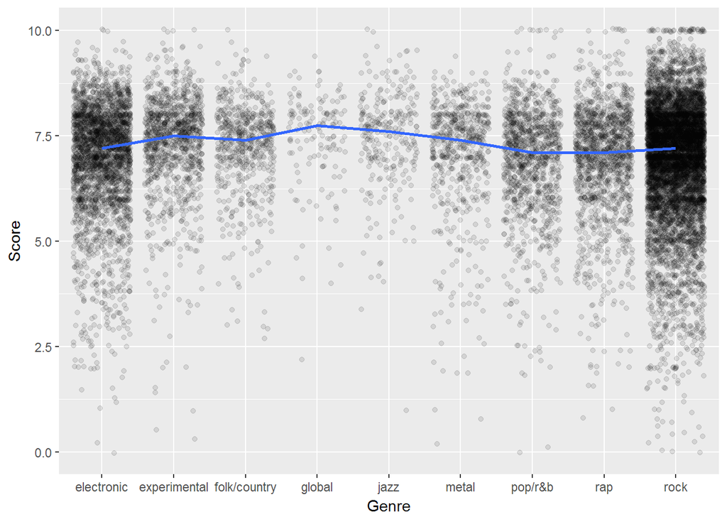

There doesn’t seem to be much prejudice for or against any particular genre in terms of score, although rock predominates in terms of sheer number of albums reviewed.

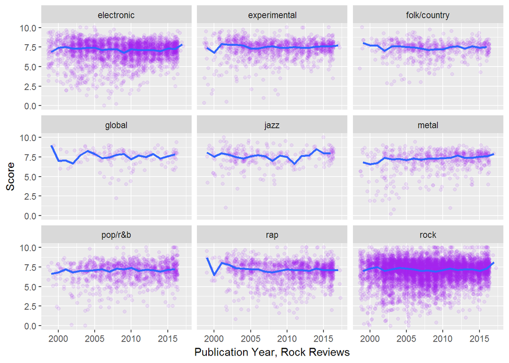

```
## # A tibble: 10 × 3
##           genre median_scores mean_scores
##          <fctr>         <dbl>       <dbl>
## 1                        7.20    7.017463
## 2    electronic          7.20    6.958034
## 3  experimental          7.50    7.325416
## 4  folk/country          7.40    7.233116
## 5        global          7.75    7.431250
## 6          jazz          7.60    7.459273
## 7         metal          7.40    7.046050
## 8       pop/r&b          7.10    6.905940
## 9           rap          7.10    6.926327
## 10         rock          7.20    6.957223
```

There’s not much of a distinction here. What I AM curious to look at is how the genres of albums Pitchfork has reviewed has changed over the years. Someone recently remarked to me that Pitchfork has “a pre-woke phase and a woke phase”, so I’m wondering if this bears out in the genre allotment.

```
## # A tibble: 1 × 1
##       n
##   <int>
## 1 34596
```

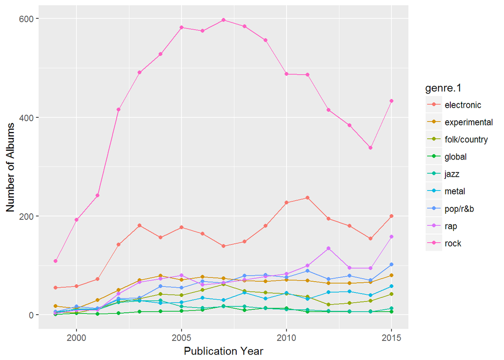

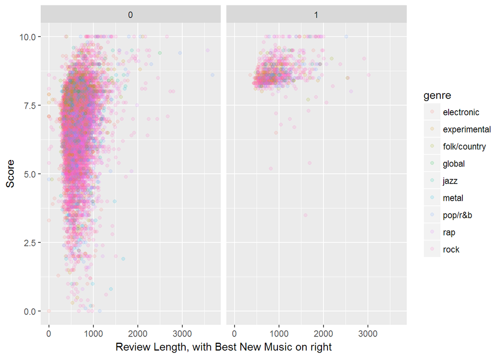

This data doesn’t include albums for which there was no genre info, and of course, overlapping genres were removed when we did the cleaning. Still, what remains is considered a very large sample of the dataset. Between this graph and the last, we can see a few things:

1. Rock predominantes, although
2. every other genre appears to be growing vis-a-vis 2000, particularly rap and electronic.
3. Pitchfork reviews so few jazz albums that it probably should not review jazz.
4. Speaking of which, there’s no contemporary classical (maybe it fell under ‘experimental’ lol).
5. Metal should probably just be merged into the rock category, so if we mentally do that, then rock is even bigger.
6. Pitchfork has peaked maybe?

BTW, this is how Radiohead has fared over the years:

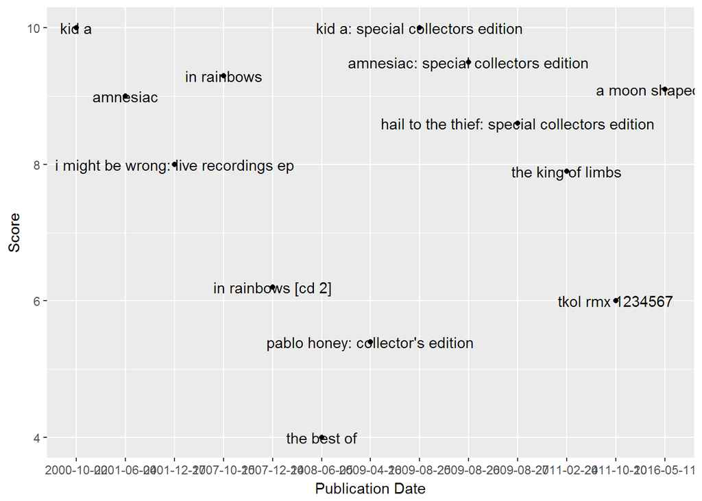

## Author Type

We can also examine whether differnet types of writers are more exacting in their critiques.

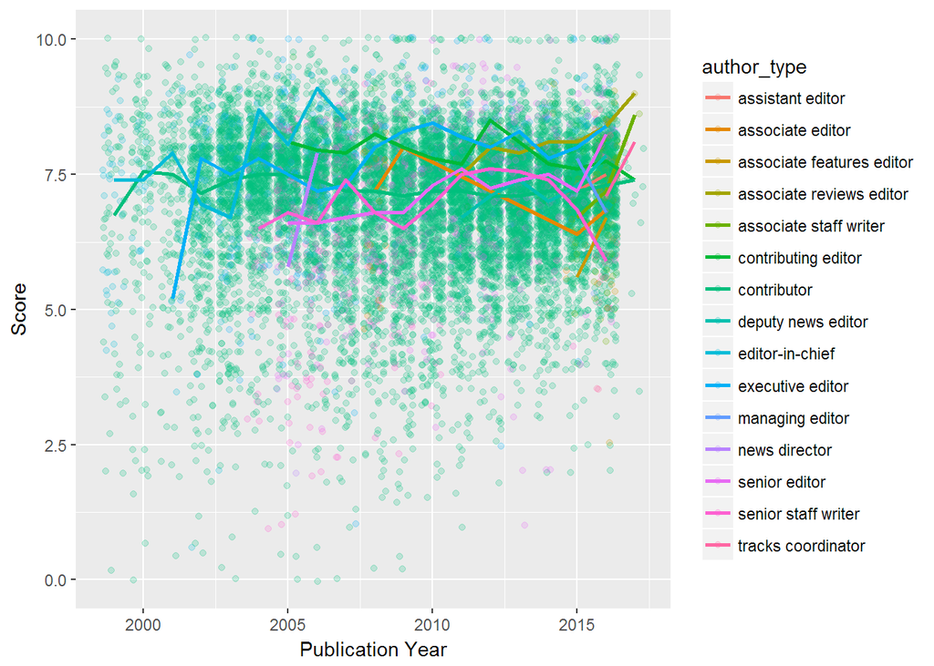

This is a pretty but unintelligible graph—the only thing that comes through the noise is how much Pitchfork relies on freelancers. Let’s look only at each individual category.

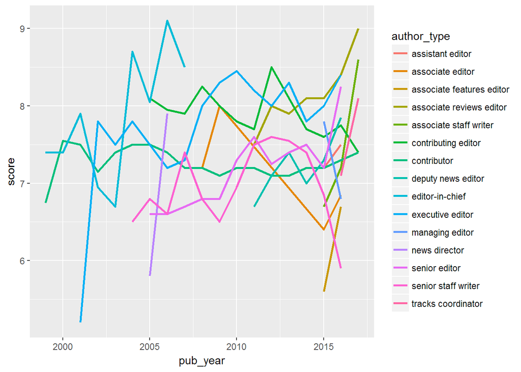

Similarly, the problem with this graph is that Pitchfork’s masthead, like that of every other publication, is so clogged with honorifics and petty editorial distinctions that RStudio practically runs out of space on the color spectrum to represent every editorial role. Viewed glancingly, the graph makes the associate reviews editor ca. 2016 look far more generous than th editor-in-chief ca. 2000. The problem, however, is that this graph doesn’t really incorporate the sense of scale of author type while reminaing readable. We can do that as such:

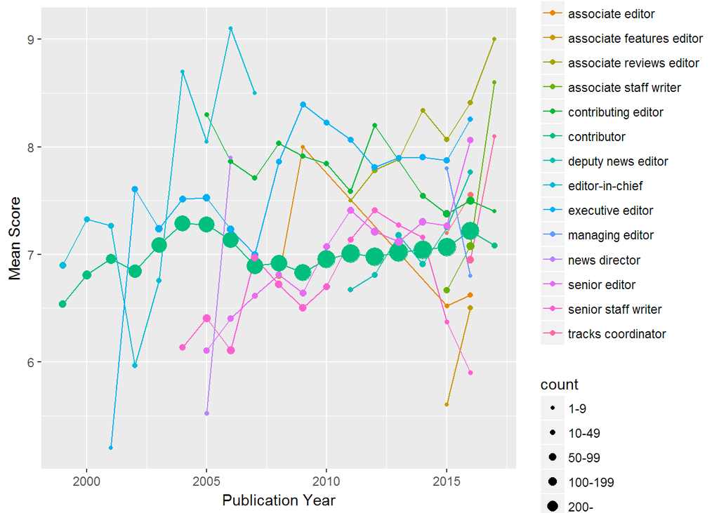

```
##                  author_type pub_year mean_score count
## 19          assistant editor     2015   7.200000     1
## 20          assistant editor     2016   7.553333    15
## 21          associate editor     2008   6.800000    21
## 22          associate editor     2009   8.000000     1
## 23          associate editor     2015   6.520000     5
## 24          associate editor     2016   6.620000    10
## 25 associate features editor     2015   5.600000     1
## 26 associate features editor     2016   6.500000    10
## 27  associate reviews editor     2011   7.500000     1
## 28  associate reviews editor     2012   7.784615    13
```

In many cases, author types have but a single data point for every year. So while there may be a correlation between author type and review scores, it’s not one that we can identify here.

## Frequency

Are you ready to watch the harmony of the cosmos manifest? You should be!

This is a histogram of authors based on how many articles they’ve written:

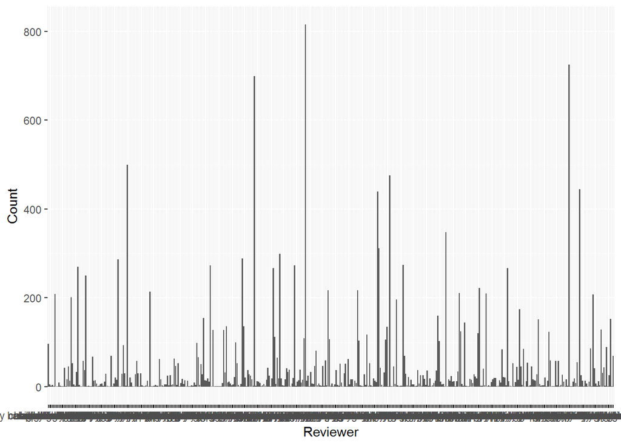

So, quite a bit of variation, with some people writing more than 800 reviews and others contributing only one. This is the total number of articles written by the top 20 percent of writers:

```
## [1] 14755
```

```
##           n
## 1 0.8023819
```

Almost exactly 80 percent! It’s the Pareto Principle before our eyes. Now, what follows is the average score of every writer as a function of number of articles written—in other words, a single point is a single writer, their positions along the x-axis are determined by the number of articles they wrote, and their positions on the y-axis by the average score they gave to albums.

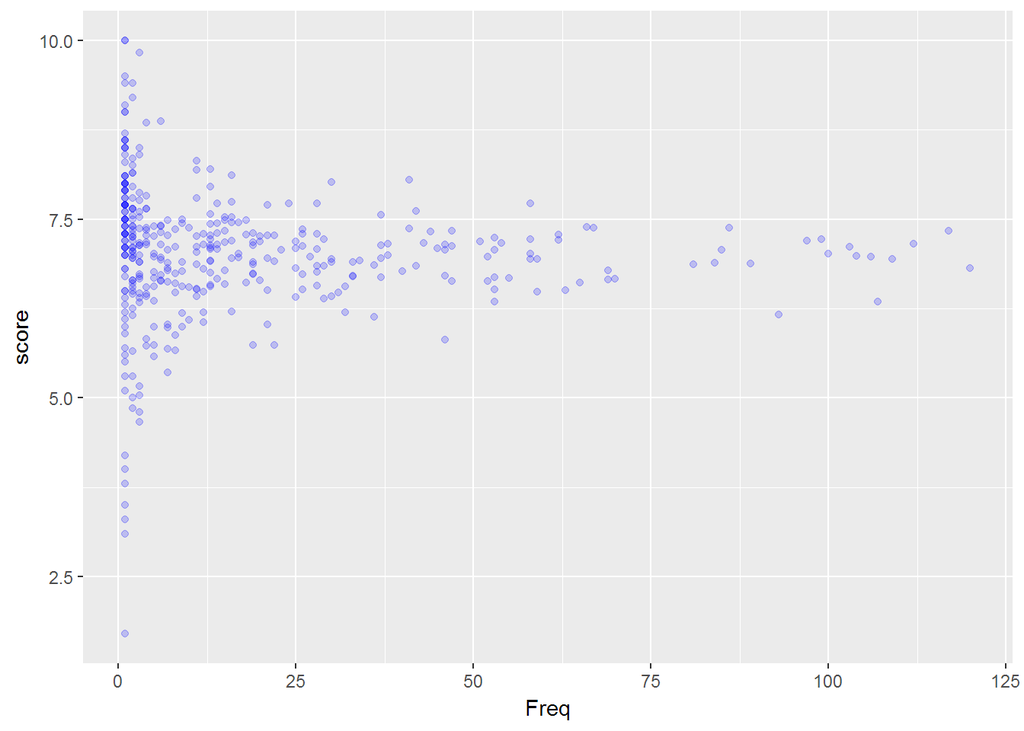

See how quickly the scores regress to the mean? It’s the Central Limit Theorem! Recall that the CLT states that over sufficient time, a sample of averages of a data set of any shape will ultimately plot along a normal distribution. This looks pretty normal to me! (Note: this chart excluded the top 5 percent of writers for the sake of scale, but they also fall into the long center of the mean.)

```
##
##  Pearson's product-moment correlation
##
## data:  writers$score and writers$Freq
## t = -0.15924, df = 421, p-value = 0.8736
## alternative hypothesis: true correlation is not equal to 0
## 95 percent confidence interval:
##  -0.10303022  0.08765028
## sample estimates:
##          cor
## -0.007760512
```

We can look at individual writers with prolific outputs to see how their scores spread across the spectrum. Here is is the chart for one Amanda Petrusich, who seems nice from Twitter:

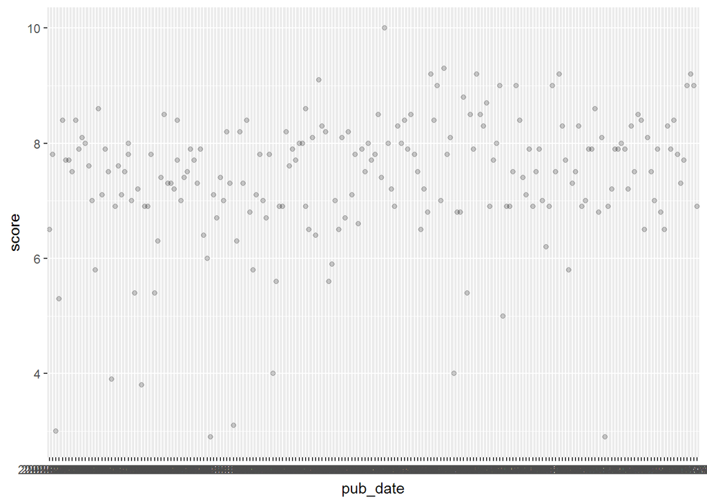

## Review Length

Could longer reviews be associated with different types of scores? Looking at the stats for length, we get:

```
##    Min. 1st Qu.  Median    Mean 3rd Qu.    Max.
##     0.0   498.0   604.0   650.1   746.0  3688.0
```

First, let’s indulge ourselves and figure out which album was critiqued for 3700 god damn words.

```
##       reviewid     title          artist
## 17756    22044 dangerous michael jackson
##                                                        url score
## 17756 http://pitchfork.com/reviews/albums/22044-dangerous/   8.6
##       best_new_music     author author_type   pub_date pub_weekday pub_day
## 17756              0 jeff weiss contributor 2016-08-07           6       7
##       pub_month pub_year   genre label length
## 17756         8     2016 pop/r&b  epic   3688
```

Actually that makes sense given the posthumous date and now I feel bad for swearing. Anyway, let’s chart our data and see what happens.

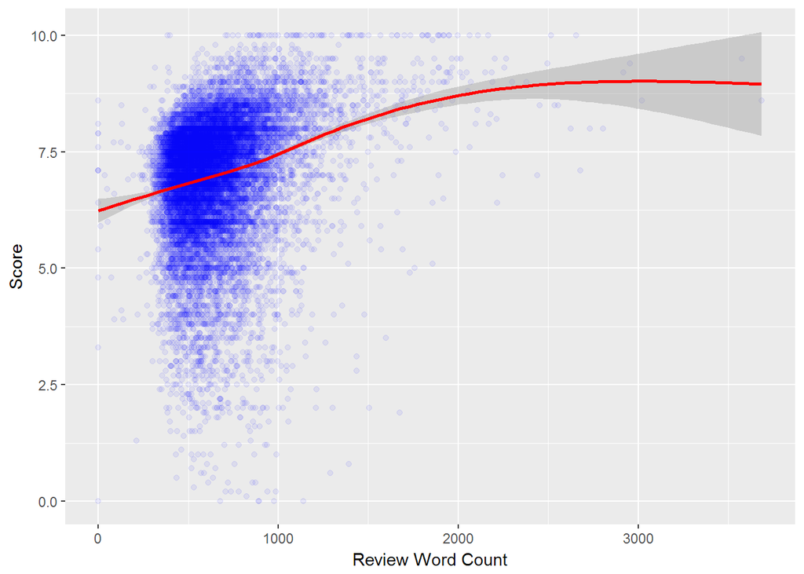

It looks like we have found something! Here are some descriptive stats on the top 20 percent and bottom 20 percent of review scores, respectively:

```
##    Min. 1st Qu.  Median    Mean 3rd Qu.    Max.
##     0.0   604.0   743.0   806.8   923.0  3688.0
```

```
##    Min. 1st Qu.  Median    Mean 3rd Qu.    Max.
##     0.0   482.0   583.0   616.2   717.0  1858.0
```

As we can see, the differences are substantial. If we run a test for correlation on the two variables, we get:

```
##
##  Pearson's product-moment correlation
##
## data:  reviews$length and reviews$score
## t = 31.195, df = 18387, p-value < 2.2e-16
## alternative hypothesis: true correlation is not equal to 0
## 95 percent confidence interval:
##  0.2104259 0.2378803
## sample estimates:
##       cor
## 0.2241976
```

In other words, there’s a correlation. Logically, this makes sense: A writer will gush about an album s/he has fallen in love with, while a bad album is more likely (though certainly not always) to be quickly dispatched. For example, see that one way down in the bottom left corner? If I recall correctly, that would be faux-leather Top 40 mistress Jet, which Pitchfork treated with a 0-point review and a nothing more than a .gif of a chimpanzee pissing into its own mouth.

```r
subset(reviews, score == 0 & length == 0)
```

```
##      reviewid    title artist
## 6054     9464 shine on    jet
##                                                     url score
## 6054 http://pitchfork.com/reviews/albums/9464-shine-on/     0
##      best_new_music     author author_type   pub_date pub_weekday pub_day
## 6054              0 ray suzuki contributor 2006-10-02           0       2
##      pub_month pub_year      genre   label length
## 6054        10     2006 electronic elektra      0
```

LOL

## Time of Review

Have reviews as a whole gotten more or less generous over time, or do they change depending on which month or where in the month they happen?

[figure not shown]

Doesn’t seem like it. Next.

## Artist scores over time

One hypothesis is that artists peak and then fall. Let’s see if this is obvious just from a graph of artists who have produced 12 or more albums.

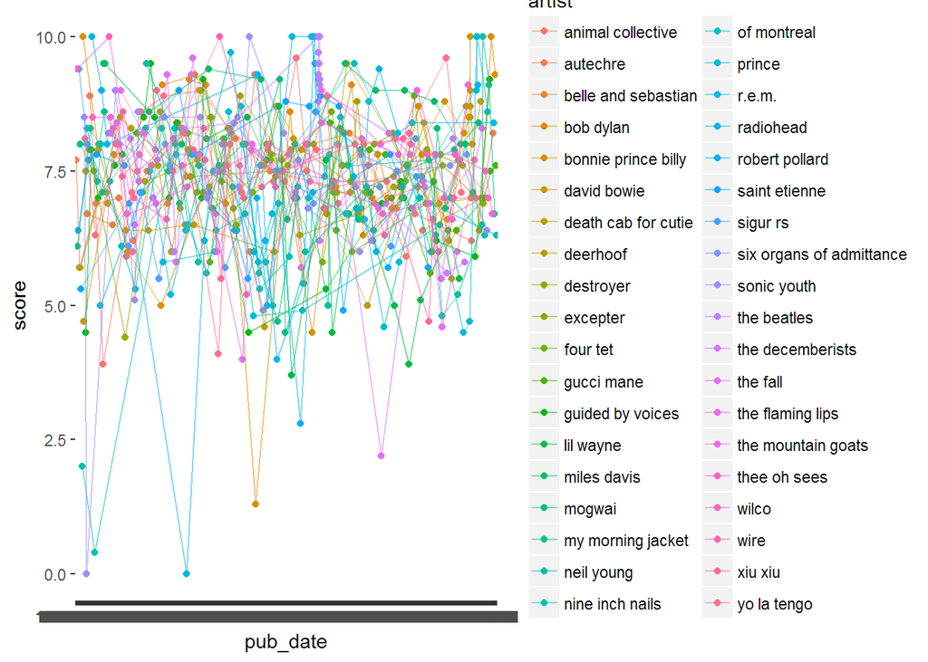

Nope! Putting aside nonquantitative points from this graphic, like why there are more than 12 Belle and Sebastian albums in existence or what value a Pitchfork review on Gucci Mane could hold, this is too illegibile to tell us anything. We can do a few things to fix it. First, we can manipulate our dataframe a bit so that albums are not only ordered by release date, but by where in the sequence of an artist’s reptertoire a given album came.

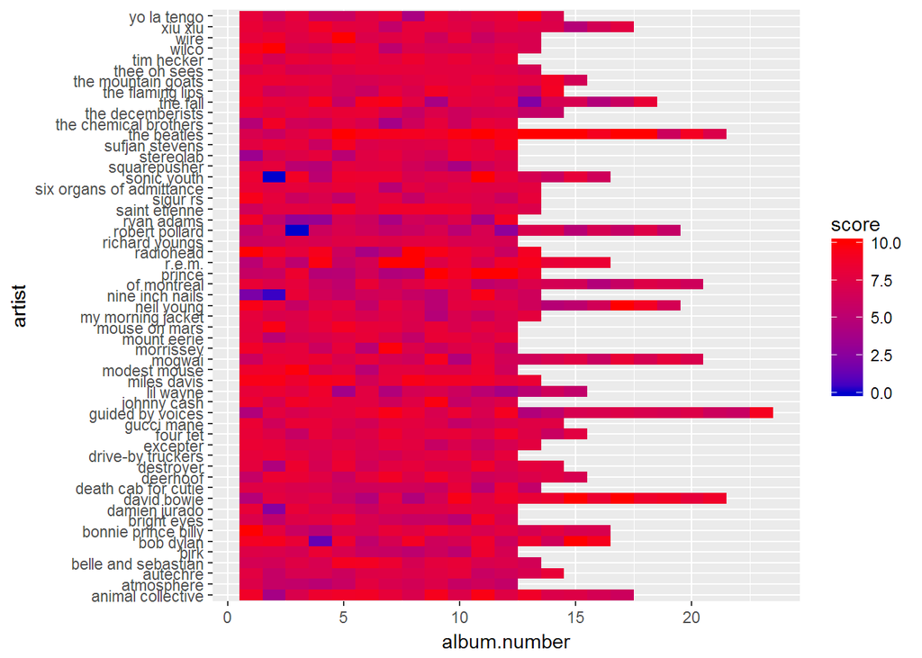

This is cool, but there’s a lot of white space. Let’s try looking at artists that have exactly 10 albums.

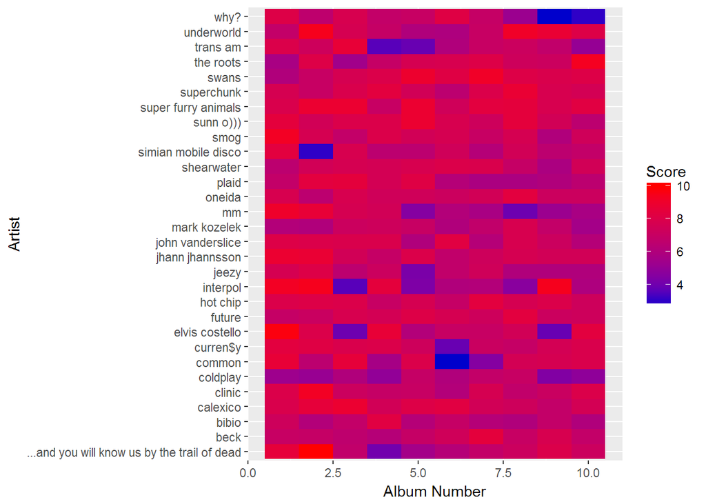

That also looks cool, and yet it’s still hard to tell if there’s a trend. The right side looks a bit bluer. One thing we can do is see look at some summary statistics of to see if the nth album on average has a lower or higher score than albums that came earlier.

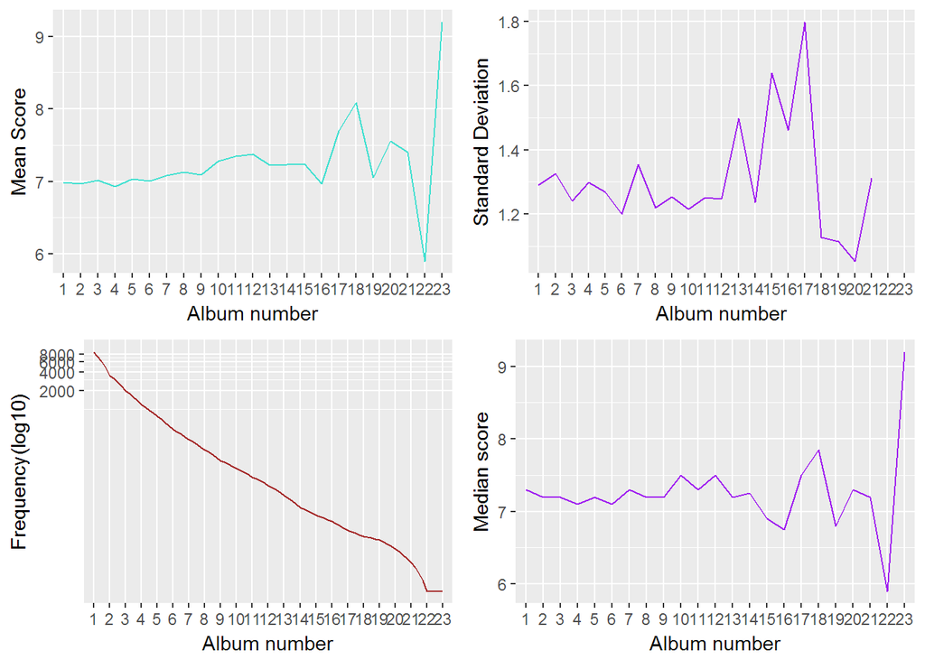

It doesn’t look like it, but it’s sort of impossible to tell with this. There are so few artists putting out 15+ albums that it’s not a decent sample. Plus, this data is arguably too aggregate to draw any meaningful conclusions from.

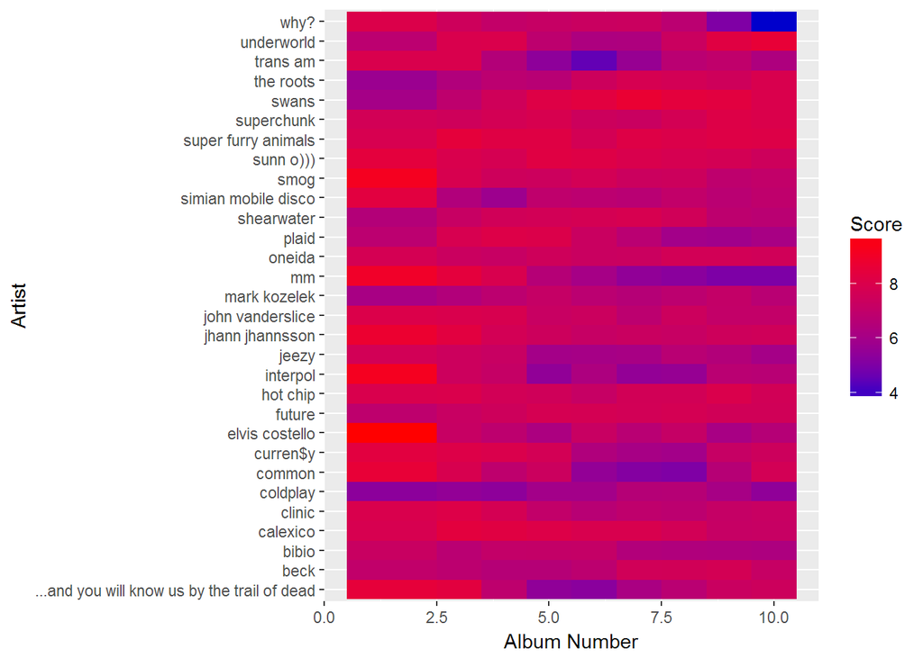

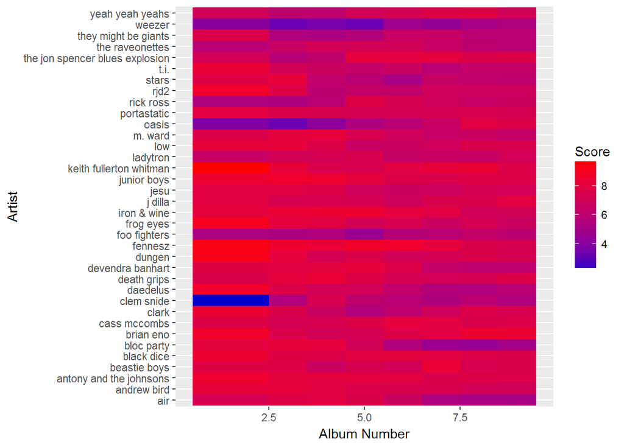

or 20

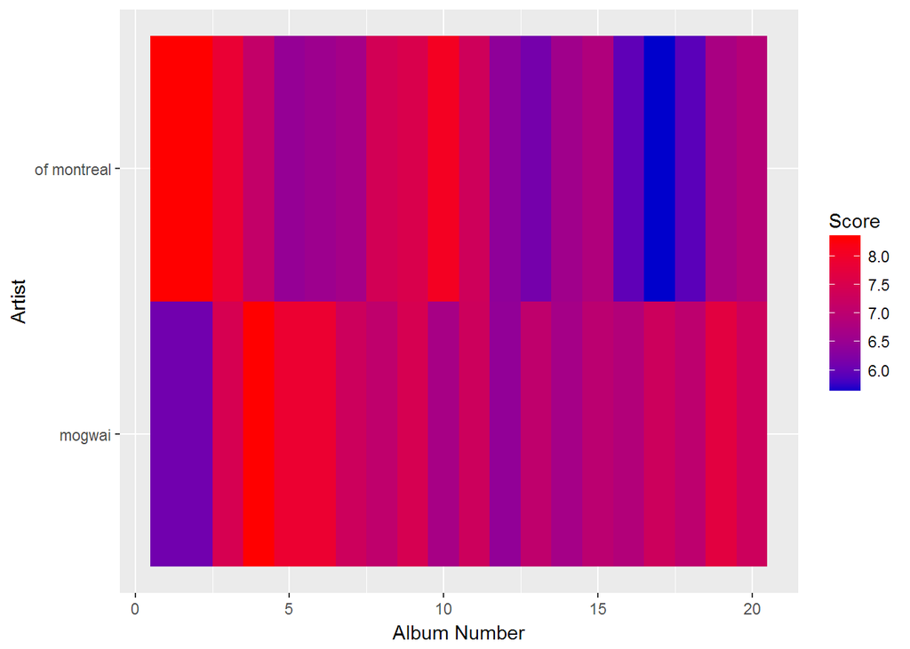

or however many.

So do albums get worse over time? It looks like, maybe??? I like to save regression analyses to the end; it forces you to find phenomena clearly visible if in fact they exist. But since we’ve been unable to do that, let’s just do a regression analysis and see what comes up, wher each color indicates a different artist.

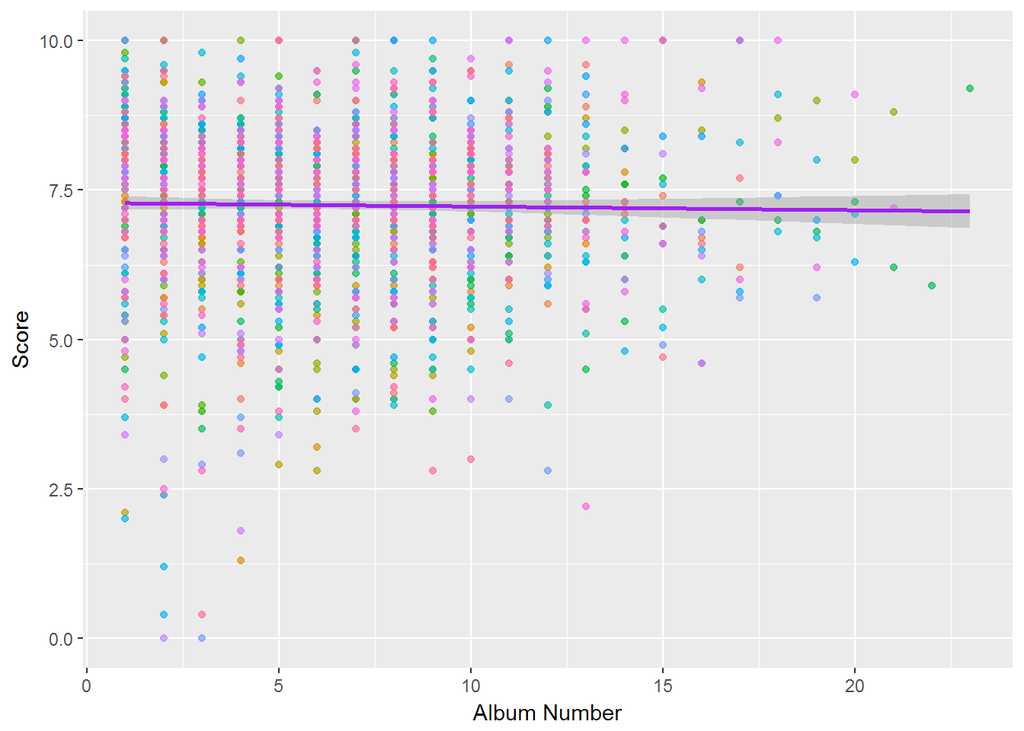

This is so horizontal that I actually have to check to make sure I was using the right code. But no, if we actually run the regression formula, we get

```
##
## Call:
## lm(formula = reviews$score ~ reviews$album.number)
##
## Coefficients:
##          (Intercept)  reviews$album.number
##             6.997580              0.000536
```

which means, no, there’s nothing to see here, either.

# Conclusion

I noticed something while playing with the dataset, and what I love about it is that after all the analysis and confronation with ggplot and facet-wrapping and tricked out multivariate scatterplots and heat maps that show nearly no measurable correlations, after all the labored deciphering of R’s cryptic, obscurantist documentation, perhaps the sole important insight from an 800 megabyte file of 18,000 rows of data can be gleaned from a single, one-line function of just four words and two numbers,

```r
head(subset(reviews, score == 10), 20)
```

[output not shown]

[output cut: 111 more lines]

Here are just the first 20 of the 76 albums in the set that have a perfect score of 10. Out of 20 albums, all but one of them were written years after the album (or the music on the album if it’s an anthology/re-release) was actually released. That’s years after the author developed their nostalgia of growing up outside Jersey City listening to the Boss croon, after the album was ushered into the national canon, after the debate over whether this was a Great Work of Art was settled. Ironic—our expedition in data science has taught us that the key lesson is that we don’t need to run a single test or plot a single chart to know that nothing is so great a predictor of who gets a 10 than the difference between the release date of the album and the date of the review. And why is that? What is even the point of assigning a score to Blood on the Tracks in 2016? Maybe it’s partly signaling, to indicate that an author is aware of just how big and important a thing is, that they have the critical eye to know a 10 when they see it. But this is Pitcfork, where, according to our calculations, the higher the score, the more likely the author will unleash a paean to an album’s glory. To dispense a 10 is to make the sign of the cross, which is why Kanye, a pesonality who has somehow convinced hoardes of critics to scramble to see which one can proclaim his genius the loudest, is one of the few active artists who regularly receives them. Tago Mago and Yeezus are now, in the litugry of Pitchfork, sancified with the acknowledgment of perfection. What’s the difference between a 7.3 and a 7.4? Nothing; the decimal points exist only to impress that the evauation of popular music is borne out with scientific rigor and outputs exact, objective, non-artificial results—that the arbitrary order imposed on something more or less orderless is in fact not arbitrary at all. But the difference between 9.9 and 10 is the distinction between measurement and worship.

All of which is to say, I think this dataset would benefit by having more data on the difference between publication date and release date, if someone with the web scraping skills were so inclined.